# Pima Indians Diabetes - Data Exploration

The Pima Indians Diabetes Dataset involves predicting the onset of diabetes within 5 years in Pima Indians given medical details. It is a binary(2 - class) classification problem.

The number of observations for each class is not balanced.

There are 768 observations with 8 input variables and 1 output variable. Missing values are believed to be encoded with zero values. The variable names are as follows:

1. Number of times pregnant.
2. Plasma glucose concentration a 2 hours in an oral glucose tolerance test.
3. Diastolic blood pressure(mm Hg) .
4. Triceps skinfold thickness(mm) .
5. 2 - Hour serum insulin(mu U / ml) .
6. Body mass index(weight in kg / (height in m) ^ 2) .
7. Diabetes pedigree function.
8. Age(years) .
9. Class variable(0 or 1) .

The baseline performance of predicting the most prevalent class is a classification accuracy of approximately 65%.

Top results achieve a classification accuracy of approximately 77%.

# Descriptive Statistics

## Data Peek

|  | pregnant | glucose | pressure | triceps | insulin | mass | pedigree | age | diabetes |
| --- | --- | --- | --- | --- | --- | --- | --- | --- | --- |
| 1 | 6 | 148 | 72 | 35 | 0 | 33.6 | 0.627 | 50 | pos |
| 2 | 1 | 85 | 66 | 29 | 0 | 26.6 | 0.351 | 31 | neg |
| 3 | 8 | 183 | 64 | 0 | 0 | 23.3 | 0.672 | 32 | pos |
| 4 | 1 | 89 | 66 | 23 | 94 | 28.1 | 0.167 | 21 | neg |
| 5 | 0 | 137 | 40 | 35 | 168 | 43.1 | 2.288 | 33 | pos |
| 6 | 5 | 116 | 74 | 0 | 0 | 25.6 | 0.201 | 30 | neg |
| 7 | 3 | 78 | 50 | 32 | 88 | 31.0 | 0.248 | 26 | pos |
| 8 | 10 | 115 | 0 | 0 | 0 | 35.3 | 0.134 | 29 | neg |
| 9 | 2 | 197 | 70 | 45 | 543 | 30.5 | 0.158 | 53 | pos |
| 10 | 8 | 125 | 96 | 0 | 0 | 0.0 | 0.232 | 54 | pos |
| 11 | 4 | 110 | 92 | 0 | 0 | 37.6 | 0.191 | 30 | neg |
| 13 | 10 | 139 | 80 | 0 | 0 | 27.1 | 1.441 | 57 | neg |
| 14 | 1 | 189 | 60 | 23 | 846 | 30.1 | 0.398 | 59 | pos |
| 15 | 5 | 166 | 72 | 19 | 175 | 25.8 | 0.587 | 51 | pos |
| 16 | 7 | 100 | 0 | 0 | 0 | 30.0 | 0.484 | 32 | pos |
| 17 | 0 | 118 | 84 | 47 | 230 | 45.8 | 0.551 | 31 | pos |
| 18 | 7 | 107 | 74 | 0 | 0 | 29.6 | 0.254 | 31 | pos |
| 20 | 1 | 115 | 70 | 30 | 96 | 34.6 | 0.529 | 32 | pos |
| 21 | 3 | 126 | 88 | 41 | 235 | 39.3 | 0.704 | 27 | neg |
| 22 | 8 | 99 | 84 | 0 | 0 | 35.4 | 0.388 | 50 | neg |

Data has a variety of scales. Consider standardization.

## Response Distribution

| variable | level | count | freqs |
| --- | --- | --- | --- |
| diabetes | neg | 400 | 0.6504065 |
| diabetes | pos | 215 | 0.3495935 |
| diabetes | .NA | 0 | 0.0000000 |

## Variable Degeneracy

| variable | type | vals | nas | zero | unique | variance | nearZeroVar |
| --- | --- | --- | --- | --- | --- | --- | --- |
| pregnant | numeric | 615 | 0 | 87 | NA | 11.5 | FALSE |
| glucose | numeric | 615 | 0 | 2 | NA | 978.5 | FALSE |
| pressure | numeric | 615 | 0 | 30 | NA | 373.3 | FALSE |
| triceps | numeric | 615 | 0 | 185 | NA | 261.0 | FALSE |
| insulin | numeric | 615 | 0 | 301 | NA | 14028.9 | FALSE |
| mass | numeric | 615 | 0 | 9 | NA | 61.9 | FALSE |
| pedigree | numeric | 615 | 0 | 0 | NA | 0.1 | FALSE |
| age | numeric | 615 | 0 | 0 | NA | 135.0 | FALSE |
| diabetes | factor | 615 | 0 | 0 | 2 | NA | FALSE |

All predictors are numeric values and the response is a factor.

No missing values but many variables have zero values. Zero values for pregnant is to be expected but shouldn’t be present for pressure, triceps and insulin. Diagnostics plots should reveal if they have zero values.

## Histograms

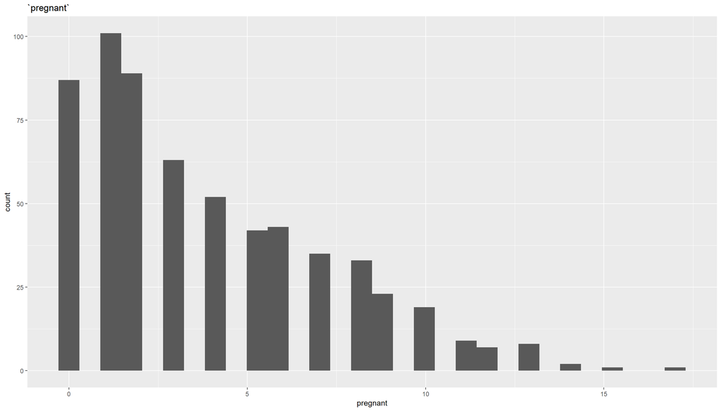

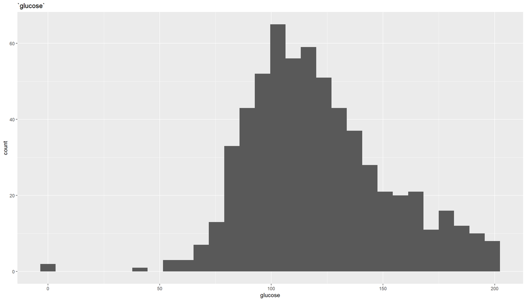

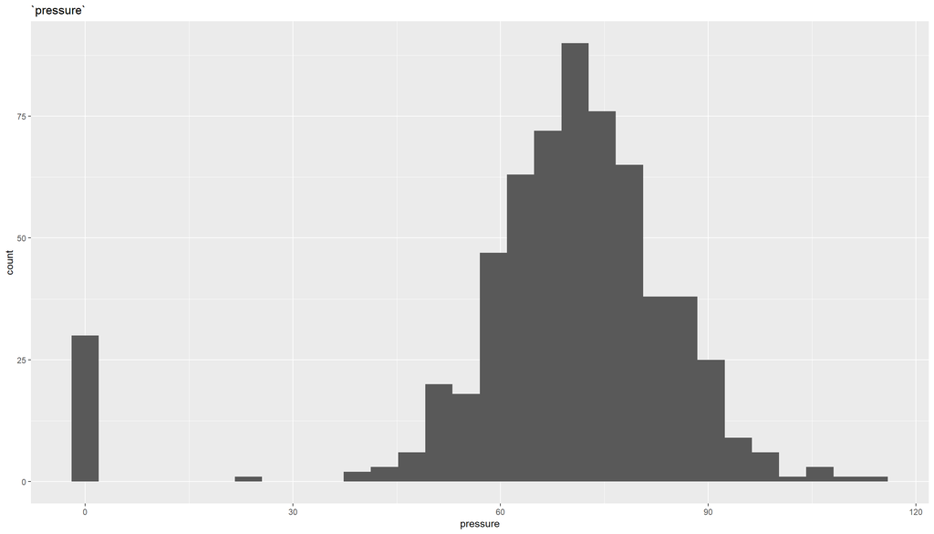

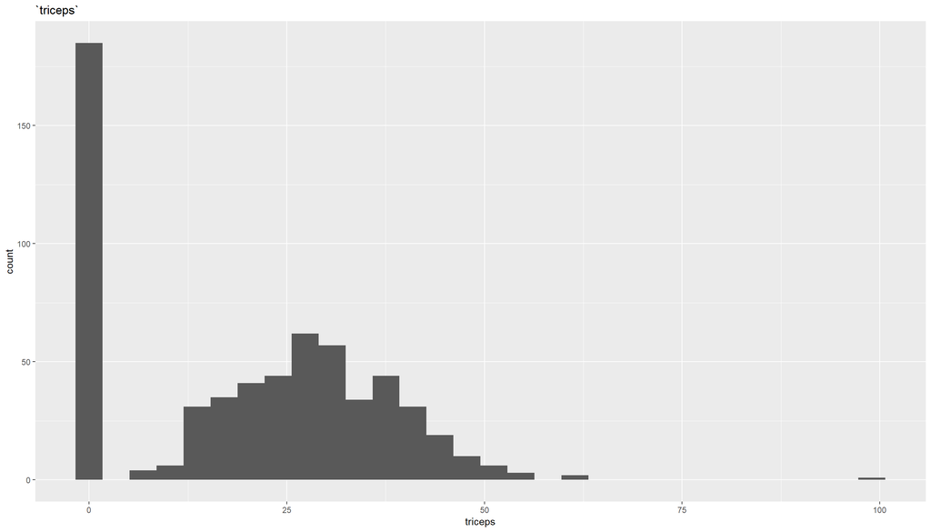

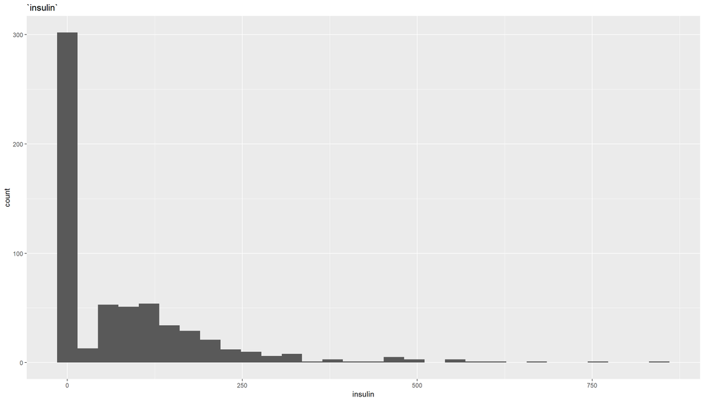

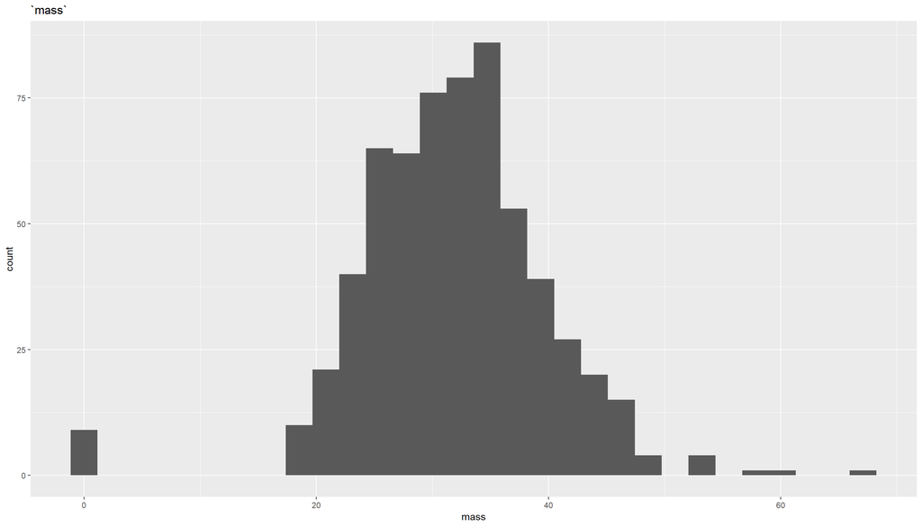

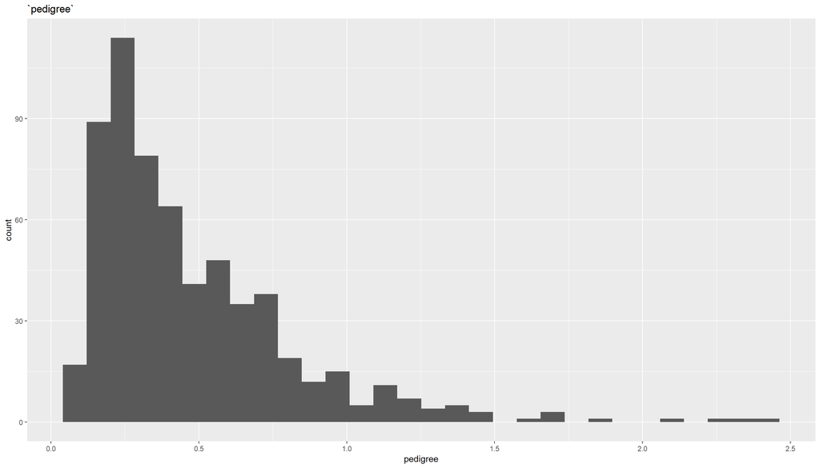

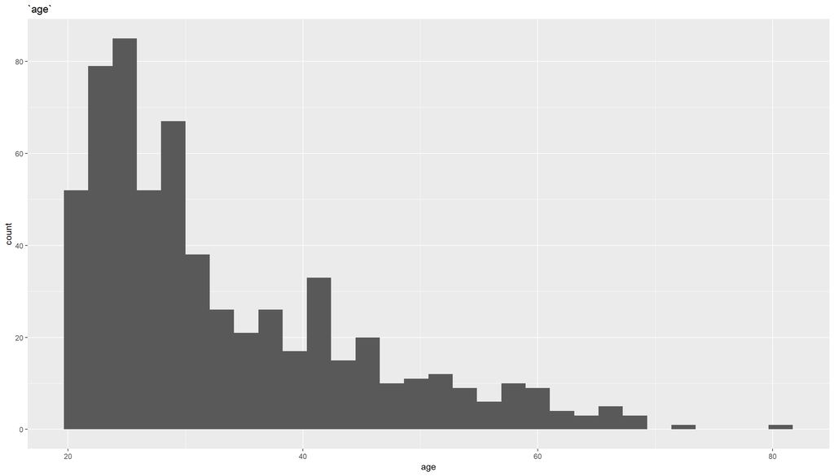

## Density

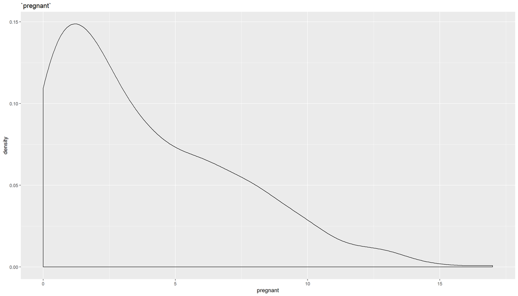

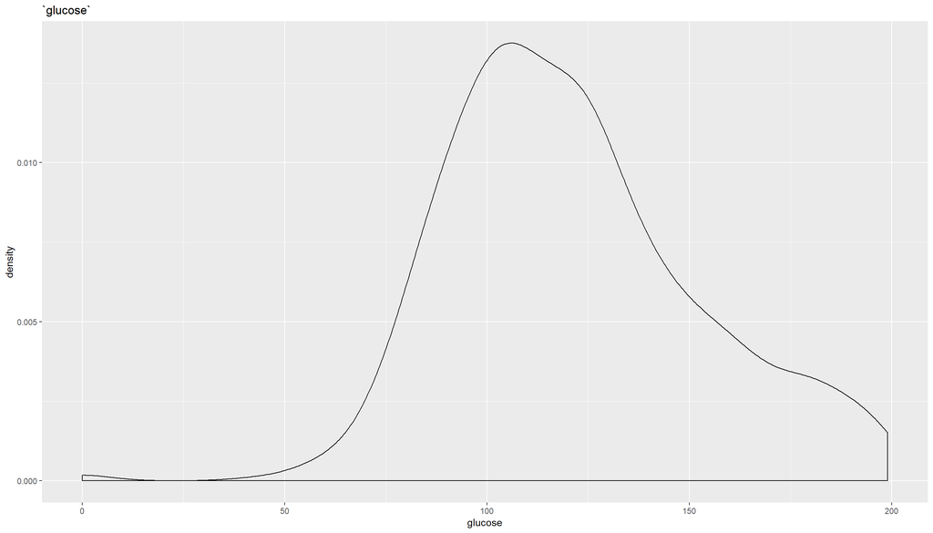

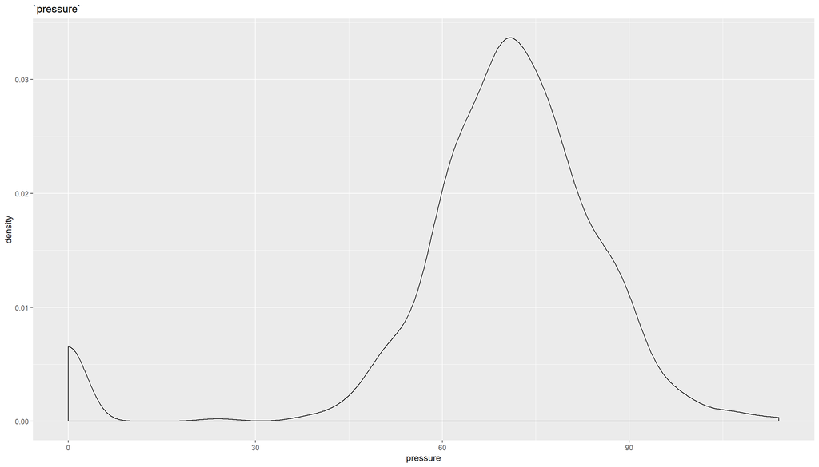

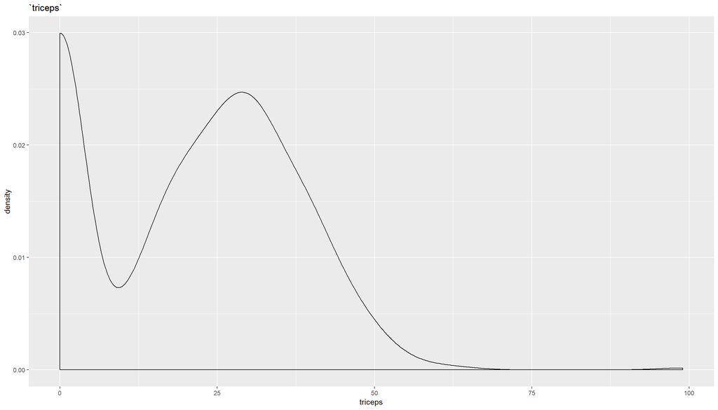

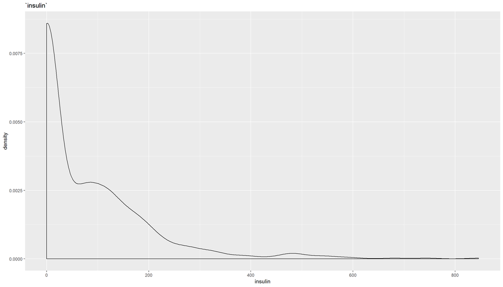

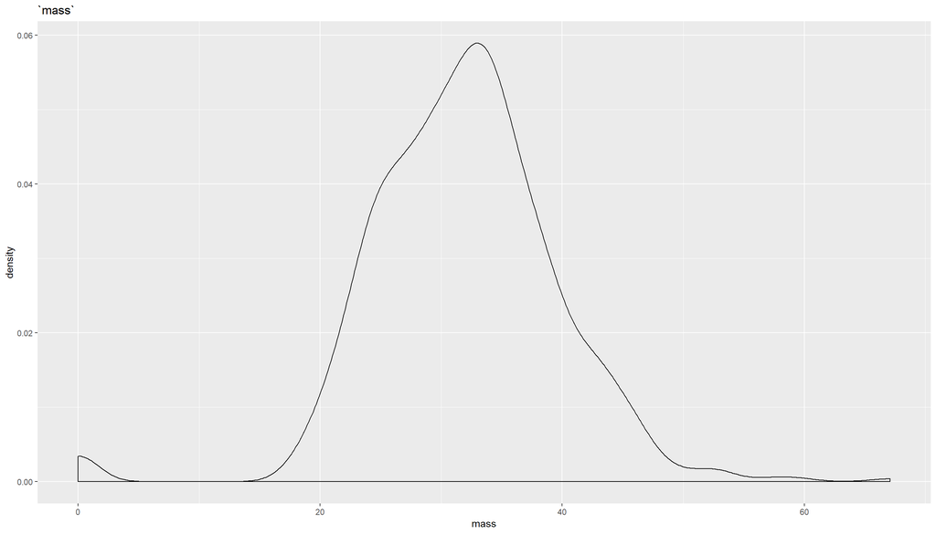

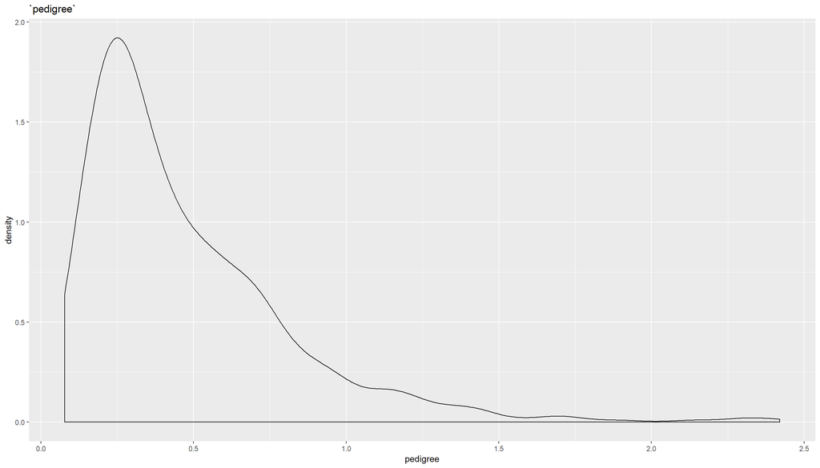

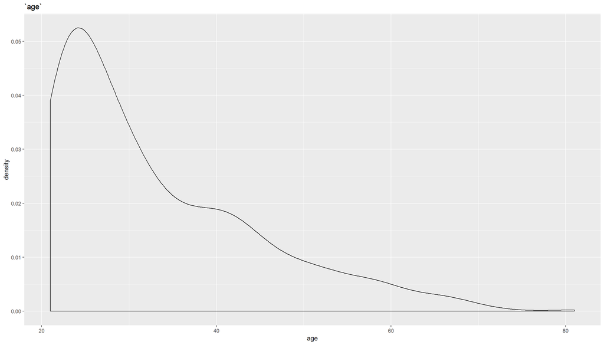

# Data Cleaning

## Clean Data Degeneracy

| variable | type | vals | nas | zero | unique | variance | nearZeroVar |
| --- | --- | --- | --- | --- | --- | --- | --- |
| pregnant | numeric | 615 | 0 | 87 | NA | 11.5 | FALSE |
| glucose | numeric | 613 | 2 | 0 | NA | NA | FALSE |
| pressure | numeric | 585 | 30 | 0 | NA | NA | FALSE |
| triceps | numeric | 430 | 185 | 0 | NA | NA | FALSE |
| insulin | numeric | 314 | 301 | 0 | NA | NA | FALSE |
| mass | numeric | 606 | 9 | 0 | NA | NA | FALSE |
| pedigree | numeric | 615 | 0 | 0 | NA | 0.1 | FALSE |
| age | numeric | 615 | 0 | 0 | NA | 135.0 | FALSE |
| diabetes | factor | 615 | 0 | 0 | 2 | NA | FALSE |

Need to fix bugs in EMC variable degeneracy function. We should still be able to get the variance.

Insulin has a large number of missing variables. Consider dropping or cross check imputation methods.

# Clean Data

## Data Peek

| pregnant | glucose | pressure | triceps | insulin | mass | pedigree | age | diabetes |
| --- | --- | --- | --- | --- | --- | --- | --- | --- |
| 6 | 148 | 72 | 35 | NA | 33.6 | 0.627 | 50 | pos |
| 1 | 85 | 66 | 29 | NA | 26.6 | 0.351 | 31 | neg |
| 8 | 183 | 64 | NA | NA | 23.3 | 0.672 | 32 | pos |
| 1 | 89 | 66 | 23 | 94 | 28.1 | 0.167 | 21 | neg |
| 0 | 137 | 40 | 35 | 168 | 43.1 | 2.288 | 33 | pos |
| 5 | 116 | 74 | NA | NA | 25.6 | 0.201 | 30 | neg |
| 3 | 78 | 50 | 32 | 88 | 31.0 | 0.248 | 26 | pos |
| 10 | 115 | NA | NA | NA | 35.3 | 0.134 | 29 | neg |
| 2 | 197 | 70 | 45 | 543 | 30.5 | 0.158 | 53 | pos |
| 8 | 125 | 96 | NA | NA | NA | 0.232 | 54 | pos |
| 4 | 110 | 92 | NA | NA | 37.6 | 0.191 | 30 | neg |
| 10 | 139 | 80 | NA | NA | 27.1 | 1.441 | 57 | neg |
| 1 | 189 | 60 | 23 | 846 | 30.1 | 0.398 | 59 | pos |
| 5 | 166 | 72 | 19 | 175 | 25.8 | 0.587 | 51 | pos |
| 7 | 100 | NA | NA | NA | 30.0 | 0.484 | 32 | pos |
| 0 | 118 | 84 | 47 | 230 | 45.8 | 0.551 | 31 | pos |
| 7 | 107 | 74 | NA | NA | 29.6 | 0.254 | 31 | pos |
| 1 | 115 | 70 | 30 | 96 | 34.6 | 0.529 | 32 | pos |
| 3 | 126 | 88 | 41 | 235 | 39.3 | 0.704 | 27 | neg |
| 8 | 99 | 84 | NA | NA | 35.4 | 0.388 | 50 | neg |

## Variable Degeneracy

| variable | type | vals | nas | zero | unique | variance | nearZeroVar |
| --- | --- | --- | --- | --- | --- | --- | --- |
| pregnant | numeric | 615 | 0 | 87 | NA | 11.5 | FALSE |
| glucose | numeric | 613 | 2 | 0 | NA | NA | FALSE |
| pressure | numeric | 585 | 30 | 0 | NA | NA | FALSE |
| triceps | numeric | 430 | 185 | 0 | NA | NA | FALSE |
| insulin | numeric | 314 | 301 | 0 | NA | NA | FALSE |
| mass | numeric | 606 | 9 | 0 | NA | NA | FALSE |
| pedigree | numeric | 615 | 0 | 0 | NA | 0.1 | FALSE |
| age | numeric | 615 | 0 | 0 | NA | 135.0 | FALSE |
| diabetes | factor | 615 | 0 | 0 | 2 | NA | FALSE |

Now we have plenty of missing values.

## Variable Distribution

| variable | type | mean | min | firstQ | median | thirdQ | max | sd | skew |
| --- | --- | --- | --- | --- | --- | --- | --- | --- | --- |
| pregnant | numeric | 3.8975610 | 0.000 | 1.0000 | 3.000 | 6.0000 | 17.00 | 3.3900954 | 0.89946015 |
| glucose | numeric | 121.4518760 | 44.000 | 99.0000 | 117.000 | 139.0000 | 199.00 | 30.5559551 | 0.54256327 |
| pressure | numeric | 72.0153846 | 24.000 | 64.0000 | 72.000 | 80.0000 | 114.00 | 11.7926479 | 0.09930038 |
| triceps | numeric | 29.2697674 | 7.000 | 22.0000 | 29.000 | 36.0000 | 99.00 | 10.7363734 | 0.82353418 |
| insulin | numeric | 158.0031847 | 14.000 | 77.2500 | 125.000 | 189.5000 | 846.00 | 123.5406440 | 2.23314755 |
| mass | numeric | 32.3438944 | 18.200 | 27.4000 | 32.250 | 36.4750 | 67.10 | 6.8941384 | 0.62794700 |
| pedigree | numeric | 0.4760878 | 0.078 | 0.2435 | 0.374 | 0.6295 | 2.42 | 0.3427841 | 1.94848926 |
| age | numeric | 33.0731707 | 21.000 | 24.0000 | 29.000 | 40.0000 | 81.00 | 11.6208918 | 1.16357327 |
| diabetes | factor | NA | NA | NA | NA | NA | NA | NA | NA |

Some skew in some variables. Some BoxCox transforms could be useful.

## Complete Data Statistics

How many complete rows do we have now?

| rows | cols |
| --- | --- |
| 313 | 9 |

313 complete rows. Enough to check correlations.

## Correlations

### Correlations matrix

```
         pregnant glucose pressure triceps insulin  mass pedigree  age
pregnant     1.00    0.15     0.19    0.09    0.07 -0.01     0.01 0.65
glucose      0.15    1.00     0.20    0.19    0.60  0.22     0.13 0.31
pressure     0.19    0.20     1.00    0.29    0.10  0.38    -0.03 0.29
triceps      0.09    0.19     0.29    1.00    0.19  0.67     0.19 0.16
insulin      0.07    0.60     0.10    0.19    1.00  0.21     0.11 0.21
mass        -0.01    0.22     0.38    0.67    0.21  1.00     0.17 0.07
pedigree     0.01    0.13    -0.03    0.19    0.11  0.17     1.00 0.10
age          0.65    0.31     0.29    0.16    0.21  0.07     0.10 1.00
```

### Corrplot

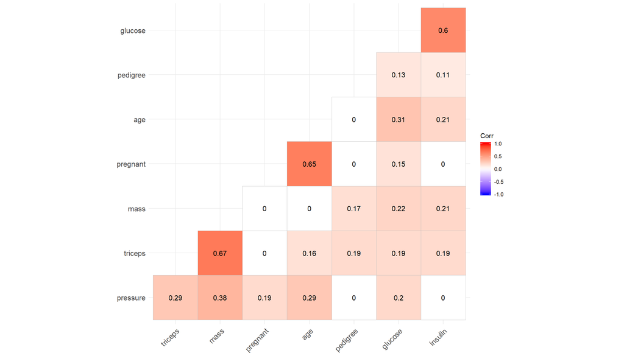

No highly correlation variables.

## Clean Data Histogram

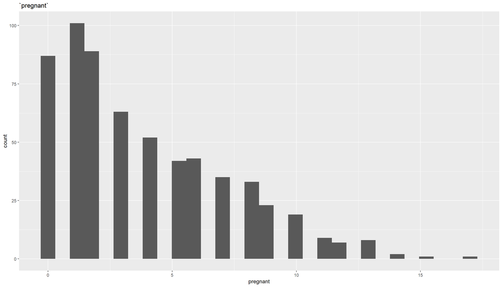

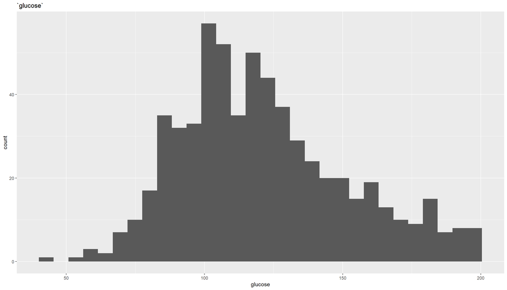

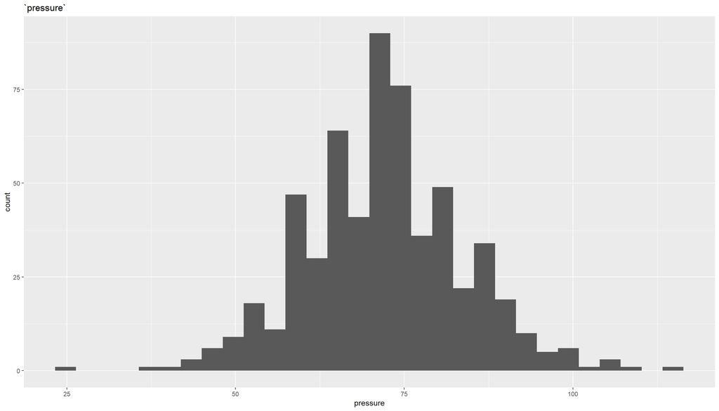

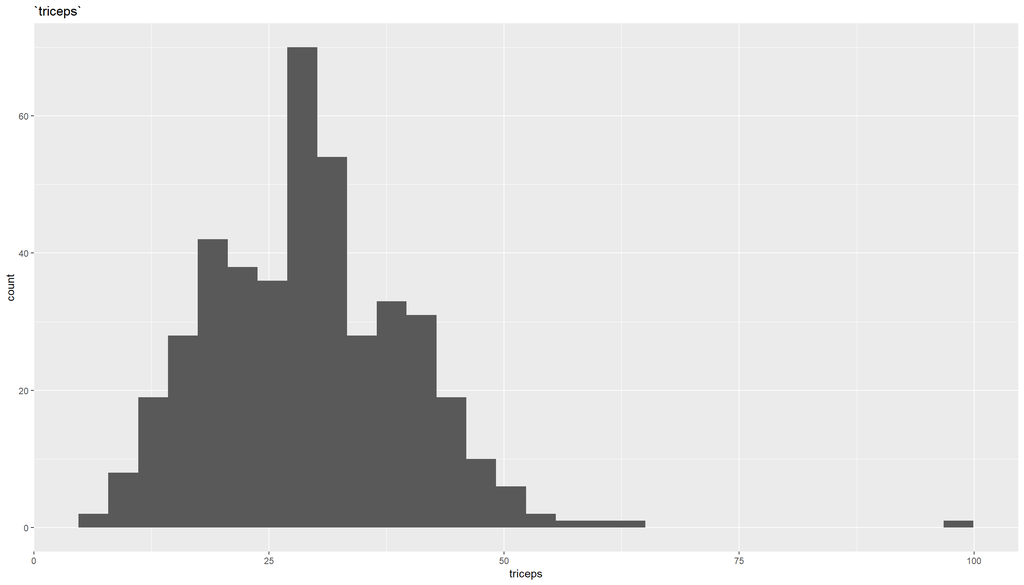

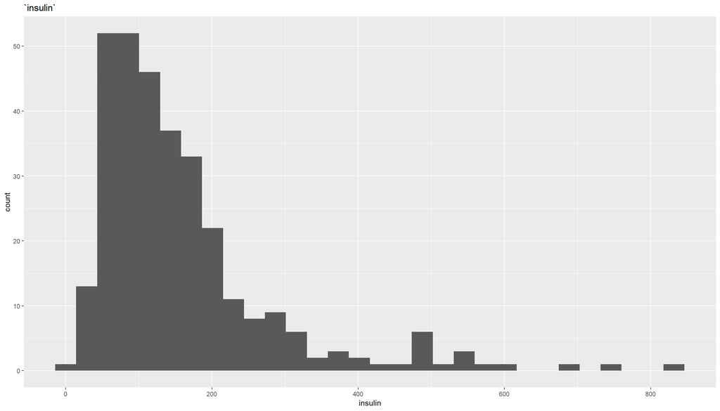

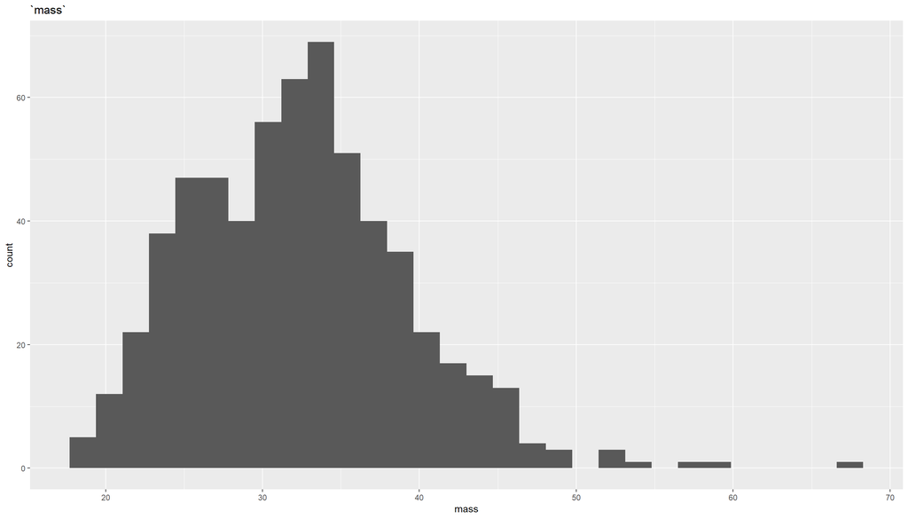

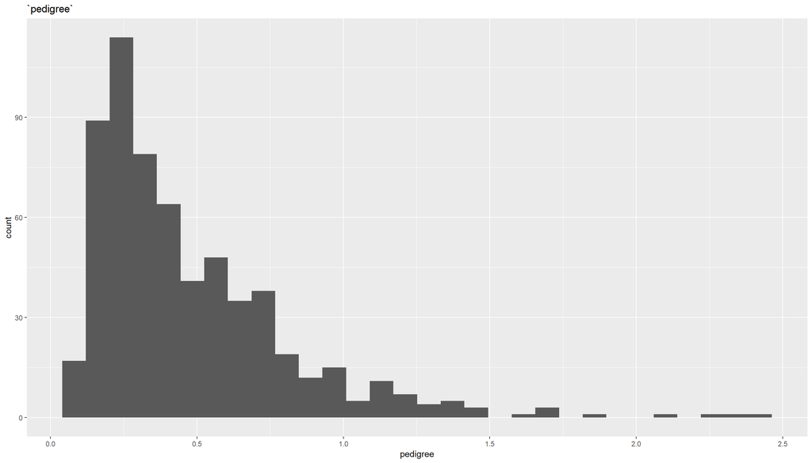

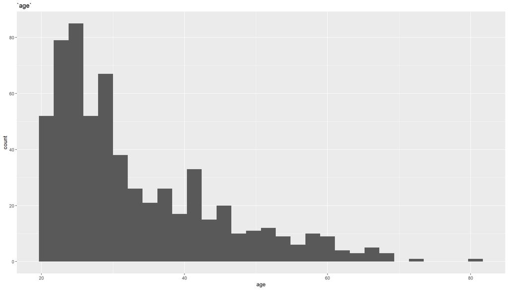